# Analysis of exposures with a neutral discourse context

This notebook analyzes the generalization patterns of novel dative-verb learners based on the factors of exposure contexts which situate the novel verb in a neutral discourse context where only the agent is given. For example:

```
DO: it was a good day . mommy [verbed] me a ball.
PP: it was a good day . mommy [verbed] a ball to me .
```

## Loading Data (code hidden)

```
 Found 255 records...
 Imported 255 records. Simplifying...
```

## Cross Dative Generalization

Investigating alternate-form generalization patterns of the learner when it is exposed to the double object dative vs. prepositional object dative.

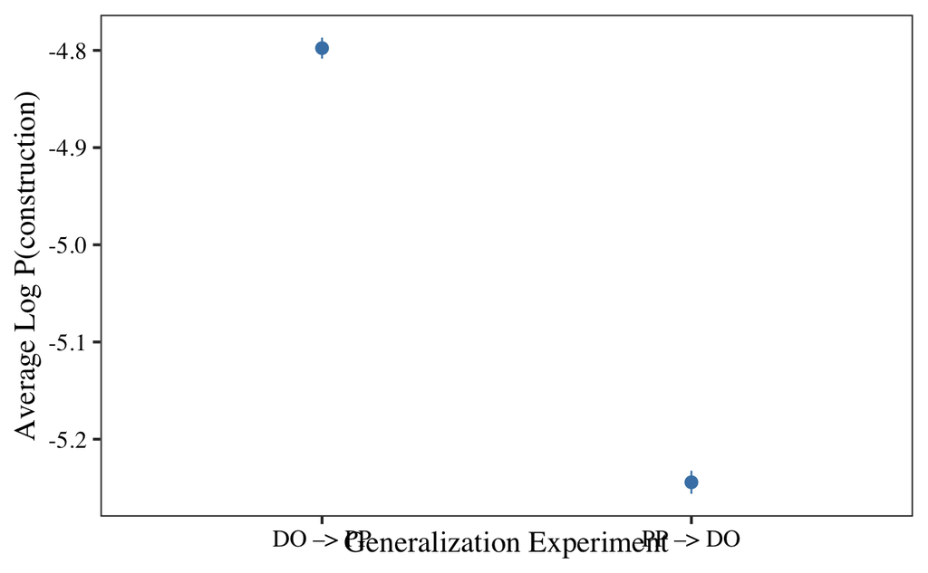

## Conwell’s “me” finding (2019):

Pronominal recipients enable DO comprehension in children, so if we were to believe that comprehension is a precondition to generalization, then pronominal recipients should also encourage generalization:

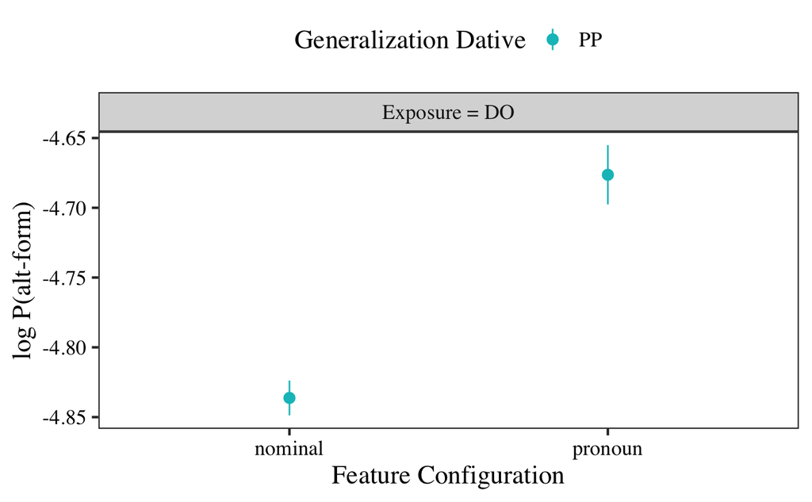

## Replicating Arunachalam (2017):

Only looking at definite themes and recipients:

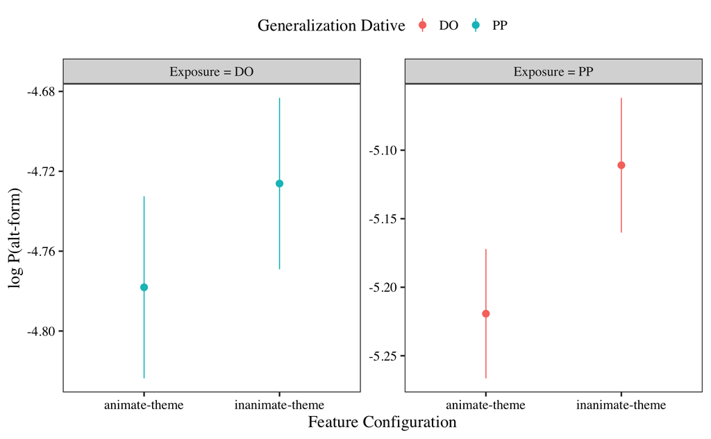

## Interaction terms

The design of interaction terms is a bit tricky. Due to our design, the pronominality might interact with the animacy of a given argument, but animacy and pronominality might also interact across arguments – e.g., if theme is inanimate then LMs might prefer animate recipients (if they are sensitive to the semantics of the dative construction – caused possession/motion). This means we should include the following interaction terms:

```
- theme_animacy * theme_pronominality
- recipient_animacy * recipient_pronominality
- theme_animacy * recipient_animacy
- theme_pronominality * recipient pronominality
```

## DO –> PP analysis

```r
do_pp <- coded_results %>%
  filter(adaptation_dative == "do", generalization_dative == "pp")

# interactions between theme-animacy and recipient animacy; theme-pronominality and recipient-pronominality

fit_tara_tprp_interaction_dopp <- lmer(best ~
                                    theme_animacy + theme_pronominality +
                                    recipient_animacy + recipient_pronominality +
                                    theme_animacy:recipient_animacy +
                                    theme_pronominality:recipient_pronominality +
                                    theme_animacy:theme_pronominality +
                                    recipient_animacy:recipient_pronominality +
                                    theme_definiteness + recipient_definiteness +
                                    theme_length  + recipient_length +
                                    (1|model), data = do_pp)

summary(fit_tara_tprp_interaction_dopp, correlation = FALSE)
```

```
Linear mixed model fit by REML. t-tests use Satterthwaite's method [
lmerModLmerTest]
Formula: best ~ theme_animacy + theme_pronominality + recipient_animacy +
    recipient_pronominality + theme_animacy:recipient_animacy +
    theme_pronominality:recipient_pronominality + theme_animacy:theme_pronominality +
    recipient_animacy:recipient_pronominality + theme_definiteness +
    recipient_definiteness + theme_length + recipient_length +      (1 | model)
   Data: do_pp

REML criterion at convergence: 19663.1

Scaled residuals:
    Min      1Q  Median      3Q     Max
-6.8866 -0.5803  0.0856  0.6920  2.5628

Random effects:
 Groups   Name        Variance Std.Dev.
 model    (Intercept) 0.01501  0.1225
 Residual             0.32542  0.5705
Number of obs: 11400, groups:  model, 10

Fixed effects:
                                              Estimate Std. Error         df
(Intercept)                                 -4.846e+00  4.288e-02  1.300e+01
theme_animacy                               -6.038e-02  1.332e-02  1.138e+04
theme_pronominality                         -4.355e-02  1.900e-02  1.138e+04
recipient_animacy                            7.195e-02  1.265e-02  1.138e+04
recipient_pronominality                      1.702e-01  1.883e-02  1.138e+04
theme_definiteness                          -2.753e-02  1.085e-02  1.138e+04
recipient_definiteness                       6.306e-02  1.084e-02  1.138e+04
theme_length                                 3.906e-02  1.252e-02  1.138e+04
recipient_length                             4.124e-02  1.277e-02  1.138e+04
theme_animacy:recipient_animacy             -8.236e-02  2.143e-02  1.138e+04
theme_pronominality:recipient_pronominality  9.298e-02  3.647e-02  1.138e+04
theme_animacy:theme_pronominality           -4.097e-03  2.665e-02  1.138e+04
recipient_animacy:recipient_pronominality   -2.175e-03  2.527e-02  1.138e+04
                                             t value Pr(>|t|)
(Intercept)                                 -113.019  < 2e-16 ***
theme_animacy                                 -4.535 5.83e-06 ***
theme_pronominality                           -2.292 0.021919 *
recipient_animacy                              5.687 1.33e-08 ***
recipient_pronominality                        9.040  < 2e-16 ***
theme_definiteness                            -2.537 0.011198 *
recipient_definiteness                         5.817 6.16e-09 ***
theme_length                                   3.120 0.001815 **
recipient_length                               3.229 0.001244 **
theme_animacy:recipient_animacy               -3.842 0.000122 ***
theme_pronominality:recipient_pronominality    2.549 0.010807 *
theme_animacy:theme_pronominality             -0.154 0.877815
recipient_animacy:recipient_pronominality     -0.086 0.931402
---
Signif. codes:  0 ‘***’ 0.001 ‘**’ 0.01 ‘*’ 0.05 ‘.’ 0.1 ‘ ’ 1
```

## PP –> DO Analysis

```r
pp_do <- coded_results %>%
  filter(adaptation_dative == "pp", generalization_dative == "do")

fit_tara_tprp_interaction_ppdo <- lmer(best ~
                                    theme_animacy + theme_pronominality +
                                    recipient_animacy + recipient_pronominality +
                                    theme_animacy:recipient_animacy +
                                    theme_pronominality:recipient_pronominality +
                                    theme_animacy:theme_pronominality +
                                    recipient_animacy:recipient_pronominality +
                                    theme_definiteness + recipient_definiteness +
                                    theme_length  + recipient_length +
                                    (1|model), data = pp_do)

summary(fit_tara_tprp_interaction_ppdo, correlation = FALSE)
```

```
Linear mixed model fit by REML. t-tests use Satterthwaite's method [
lmerModLmerTest]
Formula: best ~ theme_animacy + theme_pronominality + recipient_animacy +
    recipient_pronominality + theme_animacy:recipient_animacy +
    theme_pronominality:recipient_pronominality + theme_animacy:theme_pronominality +
    recipient_animacy:recipient_pronominality + theme_definiteness +
    recipient_definiteness + theme_length + recipient_length +      (1 | model)
   Data: pp_do

REML criterion at convergence: 21333.8

Scaled residuals:
    Min      1Q  Median      3Q     Max
-5.8036 -0.5606  0.0714  0.6881  2.6116

Random effects:
 Groups   Name        Variance Std.Dev.
 model    (Intercept) 0.01364  0.1168
 Residual             0.37691  0.6139
Number of obs: 11400, groups:  model, 10

Fixed effects:
                                              Estimate Std. Error         df
(Intercept)                                 -5.513e+00  4.188e-02  1.419e+01
theme_animacy                               -1.058e-01  1.433e-02  1.138e+04
theme_pronominality                          1.765e-01  2.045e-02  1.138e+04
recipient_animacy                            3.234e-03  1.362e-02  1.138e+04
recipient_pronominality                      2.293e-02  2.027e-02  1.138e+04
theme_definiteness                           3.324e-02  1.168e-02  1.138e+04
recipient_definiteness                       7.194e-02  1.167e-02  1.138e+04
theme_length                                 2.530e-01  1.348e-02  1.138e+04
recipient_length                             1.347e-01  1.374e-02  1.138e+04
theme_animacy:recipient_animacy             -2.227e-02  2.307e-02  1.138e+04
theme_pronominality:recipient_pronominality  9.478e-02  3.925e-02  1.138e+04
theme_animacy:theme_pronominality           -1.237e-01  2.868e-02  1.138e+04
recipient_animacy:recipient_pronominality   -7.472e-02  2.719e-02  1.138e+04
                                             t value Pr(>|t|)
(Intercept)                                 -131.616  < 2e-16 ***
theme_animacy                                 -7.384 1.65e-13 ***
theme_pronominality                            8.632  < 2e-16 ***
recipient_animacy                              0.237  0.81229
recipient_pronominality                        1.131  0.25792
theme_definiteness                             2.846  0.00444 **
recipient_definiteness                         6.166 7.23e-10 ***
theme_length                                  18.773  < 2e-16 ***
recipient_length                               9.799  < 2e-16 ***
theme_animacy:recipient_animacy               -0.965  0.33435
theme_pronominality:recipient_pronominality    2.414  0.01577 *
theme_animacy:theme_pronominality             -4.313 1.63e-05 ***
recipient_animacy:recipient_pronominality     -2.748  0.00601 **
---
Signif. codes:  0 ‘***’ 0.001 ‘**’ 0.01 ‘*’ 0.05 ‘.’ 0.1 ‘ ’ 1
```

## Attempt at displaying DO -> PP and PP -> DO in same table:

```r
tidy(fit_tara_tprp_interaction_dopp) %>%
  filter(effect == "fixed") %>%
  select(term, do_pp_estimate = estimate, do_pp_pval = p.value) %>%
  inner_join(
    tidy(fit_tara_tprp_interaction_ppdo) %>%
      filter(effect == "fixed") %>%
      select(term, pp_do_estimate = estimate, pp_do_pval = p.value)
  ) %>%
  mutate(
    # do_pp_estimate = format(do_pp_estimate , scientific=TRUE),
    # pp_do_estimate = format(pp_do_estimate, scientific=TRUE),
    do_pp_estimate = round(do_pp_estimate, 4),
    pp_do_estimate = round(pp_do_estimate, 4),
    do_pp_signif = case_when(
      do_pp_pval < 0.05 ~ "**",
      TRUE ~ as.character(round(do_pp_pval, 4))
    ),
    pp_do_signif = case_when(
      pp_do_pval < 0.05 ~ "**",
      TRUE ~ as.character(round(pp_do_pval, 4))
    )
  ) %>%
  select(term, do_pp_estimate, do_pp_signif, pp_do_estimate, pp_do_signif) %>%
  DT::datatable(options = list(pageLength = 14))
```

|  | term | do_pp_estimate | do_pp_signif | pp_do_estimate | pp_do_signif |
| --- | --- | --- | --- | --- | --- |
| 1 | (Intercept) | -4.8458 | ** | -5.5126 | ** |
| 2 | theme_animacy | -0.0604 | ** | -0.1058 | ** |
| 3 | theme_pronominality | -0.0435 | ** | 0.1765 | ** |
| 4 | recipient_animacy | 0.0719 | ** | 0.0032 | 0.8123 |
| 5 | recipient_pronominality | 0.1702 | ** | 0.0229 | 0.2579 |
| 6 | theme_definiteness | -0.0275 | ** | 0.0332 | ** |
| 7 | recipient_definiteness | 0.0631 | ** | 0.0719 | ** |
| 8 | theme_length | 0.0391 | ** | 0.253 | ** |
| 9 | recipient_length | 0.0412 | ** | 0.1347 | ** |
| 10 | theme_animacy:recipient_animacy | -0.0824 | ** | -0.0223 | 0.3344 |

[output cut: 3 more lines]